# R Notebook

## Loading packages

```r
library(AppliedPredictiveModeling)
library (tidyverse)
library(psych)
library(rpart)
library (caret)
library(pamr)
library(rpart.plot)
library(pROC)
library(MLmetrics)
library(GGally)
library(imputeMissings)
```

Data Set Information:

This data set contains 416 liver patient records and 167 non liver patient records.The data set was collected from north east of Andhra Pradesh, India. Selector is a class label used to divide into groups(liver patient or not). This data set contains 441 male patient records and 142 female patient records.

Any patient whose age exceeded 89 is listed as being of age “90”.

Attribute Information:

1. Age Age of the patient
2. Gender Gender of the patient
3. TB Total Bilirubin
4. DB Direct Bilirubin
5. Alkphos Alkaline Phosphotase
6. Sgpt Alamine Aminotransferase
7. Sgot Aspartate Aminotransferase
8. TP Total Protiens
9. ALB Albumin
10. A/G Ratio Albumin and Globulin Ratio
11. Selector field used to split the data into two sets (labeled by the experts)

## Loading dataset

```r
ilpd <- read.csv("Indian Liver Patient Dataset (ILPD).csv",
               header = FALSE)
colnames(ilpd) = c("age", "gender", "tb", "db", "alkphos", "sgpt", "sgot", "tp", "alb", "ag_ratio", "selector")
```

## EDA (graphical and non-graphical representations of relationships between response variable and predictor variables)

```r
glimpse(ilpd)
```

```
Rows: 583
Columns: 11
$ age      <int> 65, 62, 62, 58, 72, 46, 26, 29, 17, 55, 57, 72, 64, 74,~
$ gender   <chr> "Female", "Male", "Male", "Male", "Male", "Male", "Fema~
$ tb       <dbl> 0.7, 10.9, 7.3, 1.0, 3.9, 1.8, 0.9, 0.9, 0.9, 0.7, 0.6,~
$ db       <dbl> 0.1, 5.5, 4.1, 0.4, 2.0, 0.7, 0.2, 0.3, 0.3, 0.2, 0.1, ~
$ alkphos  <int> 187, 699, 490, 182, 195, 208, 154, 202, 202, 290, 210, ~
$ sgpt     <int> 16, 64, 60, 14, 27, 19, 16, 14, 22, 53, 51, 31, 61, 22,~
$ sgot     <int> 18, 100, 68, 20, 59, 14, 12, 11, 19, 58, 59, 56, 58, 30~
$ tp       <dbl> 6.8, 7.5, 7.0, 6.8, 7.3, 7.6, 7.0, 6.7, 7.4, 6.8, 5.9, ~
$ alb      <dbl> 3.3, 3.2, 3.3, 3.4, 2.4, 4.4, 3.5, 3.6, 4.1, 3.4, 2.7, ~
$ ag_ratio <dbl> 0.90, 0.74, 0.89, 1.00, 0.40, 1.30, 1.00, 1.10, 1.20, 1~
$ selector <int> 1, 1, 1, 1, 1, 1, 1, 1, 2, 1, 1, 1, 2, 1, 1, 2, 1, 2, 1~
```

```r
describeBy(ilpd, "selector")
```

```
 Descriptive statistics by group
selector: 1
```

|  | vars | n | mean | sd | median | trimmed | mad | min | max | range | skew | kurtosis | se |
| --- | --- | --- | --- | --- | --- | --- | --- | --- | --- | --- | --- | --- | --- |
| age | 1 | 416 | 46.15 | 15.65 | 46.00 | 46.19 | 17.79 | 7.0 | 90.0 | 83.0 | -0.02 | -0.56 | 0.77 |
| gender* | 2 | 416 | 1.78 | 0.42 | 2.00 | 1.85 | 0.00 | 1.0 | 2.0 | 1.0 | -1.34 | -0.21 | 0.02 |
| tb | 3 | 416 | 4.16 | 7.14 | 1.40 | 2.40 | 1.04 | 0.4 | 75.0 | 74.6 | 4.14 | 26.64 | 0.35 |
| db | 4 | 416 | 1.92 | 3.21 | 0.50 | 1.10 | 0.59 | 0.1 | 19.7 | 19.6 | 2.62 | 7.15 | 0.16 |
| alkphos | 5 | 416 | 319.01 | 268.31 | 229.00 | 261.60 | 88.96 | 63.0 | 2110.0 | 2047.0 | 3.32 | 13.53 | 13.15 |
| sgpt | 6 | 416 | 99.61 | 212.77 | 41.00 | 53.30 | 28.17 | 12.0 | 2000.0 | 1988.0 | 5.51 | 35.27 | 10.43 |
| sgot | 7 | 416 | 137.70 | 337.39 | 52.50 | 71.68 | 42.25 | 11.0 | 4929.0 | 4918.0 | 8.99 | 108.62 | 16.54 |
| tp | 8 | 416 | 6.46 | 1.09 | 6.55 | 6.49 | 0.96 | 2.7 | 9.6 | 6.9 | -0.30 | 0.36 | 0.05 |
| alb | 9 | 416 | 3.06 | 0.79 | 3.00 | 3.06 | 0.74 | 0.9 | 5.5 | 4.6 | 0.05 | -0.24 | 0.04 |
| ag_ratio | 10 | 414 | 0.91 | 0.33 | 0.90 | 0.89 | 0.30 | 0.3 | 2.8 | 2.5 | 1.22 | 4.33 | 0.02 |

[output cut: 1 more lines]

```
-------------------------------------------------------
selector: 2
```

|  | vars | n | mean | sd | median | trimmed | mad | min | max | range | skew | kurtosis | se |
| --- | --- | --- | --- | --- | --- | --- | --- | --- | --- | --- | --- | --- | --- |
| age | 1 | 167 | 41.24 | 17.00 | 40.0 | 41.30 | 19.27 | 4.00 | 85.0 | 81.00 | 0.06 | -0.69 | 1.32 |
| gender* | 2 | 167 | 1.70 | 0.46 | 2.0 | 1.75 | 0.00 | 1.00 | 2.0 | 1.00 | -0.87 | -1.25 | 0.04 |
| tb | 3 | 167 | 1.14 | 1.00 | 0.8 | 0.92 | 0.15 | 0.50 | 7.3 | 6.80 | 4.03 | 18.08 | 0.08 |
| db | 4 | 167 | 0.40 | 0.52 | 0.2 | 0.28 | 0.15 | 0.10 | 3.6 | 3.50 | 3.88 | 17.14 | 0.04 |
| alkphos | 5 | 167 | 219.75 | 140.99 | 186.0 | 194.39 | 37.06 | 90.00 | 1580.0 | 1490.00 | 6.02 | 50.65 | 10.91 |
| sgpt | 6 | 167 | 33.65 | 25.06 | 27.0 | 29.26 | 11.86 | 10.00 | 181.0 | 171.00 | 3.13 | 12.66 | 1.94 |
| sgot | 7 | 167 | 40.69 | 36.41 | 29.0 | 33.36 | 14.83 | 10.00 | 285.0 | 275.00 | 3.50 | 16.21 | 2.82 |
| tp | 8 | 167 | 6.54 | 1.06 | 6.6 | 6.57 | 1.04 | 3.70 | 9.2 | 5.50 | -0.22 | -0.28 | 0.08 |
| alb | 9 | 167 | 3.34 | 0.78 | 3.4 | 3.37 | 0.89 | 1.40 | 5.0 | 3.60 | -0.30 | -0.57 | 0.06 |
| ag_ratio | 10 | 165 | 1.03 | 0.29 | 1.0 | 1.02 | 0.30 | 0.37 | 1.9 | 1.53 | 0.53 | 0.58 | 0.02 |

[output cut: 1 more lines]

[output not shown]

[output cut: 114 more lines]

[output not shown]

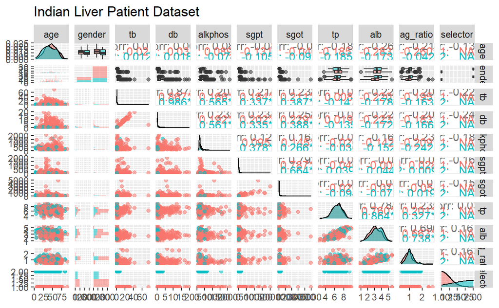

```r
g1 <- ggpairs(data=ilpd, title="Indian Liver Patient Dataset",
  mapping=ggplot2::aes(colour = as.factor(selector), alpha=0.5),
  lower=list(combo=wrap("facethist",binwidth=1)))

g1
```

## Data wrangling and pre-processing (handling of missing values, outliers, correlated features, etc.)

```r
# Creating a Dummy Variable and converting the Outcome in a factor
df <- ilpd %>%
  mutate(male = ifelse(gender == "Male", 1, 0), .after=gender) %>%
  mutate(selector = as.factor(paste0("G",selector))) %>%
  select(-gender)

# Zero- and Near Zero-Variance Predictors
who = nearZeroVar(df)
if(length(who) > 0) df <- df[,-who]

# Identifying Correlated Predictors
who = df %>%
  select(-selector) %>%
  cor(use="complete.obs") %>%
  findCorrelation(cutoff=.75)

if(length(who) > 0) df <- df[,-who]

# Linear Dependencies
who = df %>%
  select(-selector) %>%
  cov(use="complete.obs") %>%
  findLinearCombos()

if(length(who$remove) > 0) df <- df[,-who$remove]

# Imputation for missing values
df <- impute(df)

# Removing Influential Obs by Cooks distance
mod <- glm(selector ~ ., data=df, family="binomial")
cooksd <- cooks.distance(mod)
who <- cooksd > 4*mean(cooksd, na.rm=T)

if(sum(who) > 0) df <- df[-who,]

# Centering and scaling
df_clean <- df %>%
  select(-selector) %>%
  scale() %>%
  as.data.frame()

# The outcome
selector = df$selector
```

## Data splitting (training, validation, and test sets)

```r
set.seed(123)
## Partition the data with stratified sampling
training <- createDataPartition(selector, p = .8, list = FALSE)
## Partition train and test sets
df_train <- df_clean[training, ]
df_test <- df_clean[-training, ]
## Partition for the train and test sets for the response variable
selector_train <- selector[training]
selector_test <- selector[-training]
## Set training control for model building
ctrl <- trainControl(method = "repeatedcv", 10,
                     repeats = 10,
                     summaryFunction = twoClassSummary,
                     classProbs = TRUE,
                     savePredictions = TRUE)
```

KNN Model

```r
set.seed(476)
knnFit <- train(x = df_train,
               y = selector_train,
               method = "knn",
               metric = "ROC",
               trControl = ctrl)
knnFit
```

```
k-Nearest Neighbors

466 samples
  7 predictor
  2 classes: 'G1', 'G2'

No pre-processing
Resampling: Cross-Validated (10 fold, repeated 10 times)
Summary of sample sizes: 419, 420, 419, 419, 419, 420, ...
Resampling results across tuning parameters:

  k  ROC        Sens       Spec
  5  0.6883111  0.8159626  0.3950000
  7  0.6886339  0.8235651  0.3678022
  9  0.6895444  0.8190731  0.3537363

ROC was used to select the optimal model using the largest value.
The final value used for the model was k = 9.
```

```r
knnFit$finalModel
```

```
9-nearest neighbor model
Training set outcome distribution:

 G1  G2
332 134
```

## Validation and testing (model tuning and evaluation)

```r
# we will make a grid of values to test in cross-validation.
knnGrid <-  expand.grid(k = c(1:50))

set.seed(476)
knnFitTune <- train(x = df_train,
               y = selector_train,
               method = "knn",
               metric = "ROC",
               tuneGrid = knnGrid,
               trControl = ctrl)
knnFitTune
```

```
k-Nearest Neighbors

466 samples
  7 predictor
  2 classes: 'G1', 'G2'

No pre-processing
Resampling: Cross-Validated (10 fold, repeated 10 times)
Summary of sample sizes: 419, 420, 419, 419, 419, 420, ...
Resampling results across tuning parameters:

  k   ROC        Sens       Spec
   1  0.6253469  0.7710784  0.47961538
   2  0.6475370  0.7508378  0.44736264
   3  0.6629293  0.7860784  0.40450549
```

[output cut: 50 more lines]

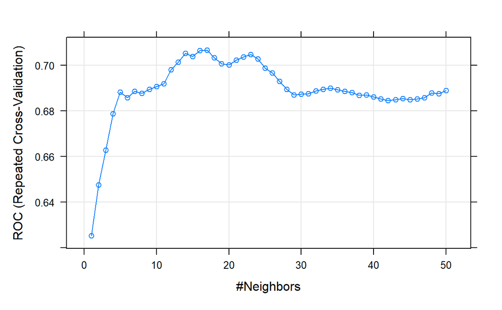

```r
plot(knnFitTune)
```

```r
knnFitTune$finalModel
```

```
17-nearest neighbor model
Training set outcome distribution:

 G1  G2
332 134
```

## Results and final model selection (performance measures, etc.)

```r
knnCM <- confusionMatrix(knnFitTune, norm = "none")
knnCM
```

```
Cross-Validated (10 fold, repeated 10 times) Confusion Matrix

(entries are un-normalized aggregated counts)

          Reference
Prediction   G1   G2
        G1 2885 1028
        G2  435  312

 Accuracy (average) : 0.6861
```

```r
## Plot the ROC curve for the hold-out set
knnRoc <- roc(response = knnFitTune$pred$obs,
             predictor = knnFitTune$pred$G1,
             levels = levels(knnFitTune$pred$obs))
```

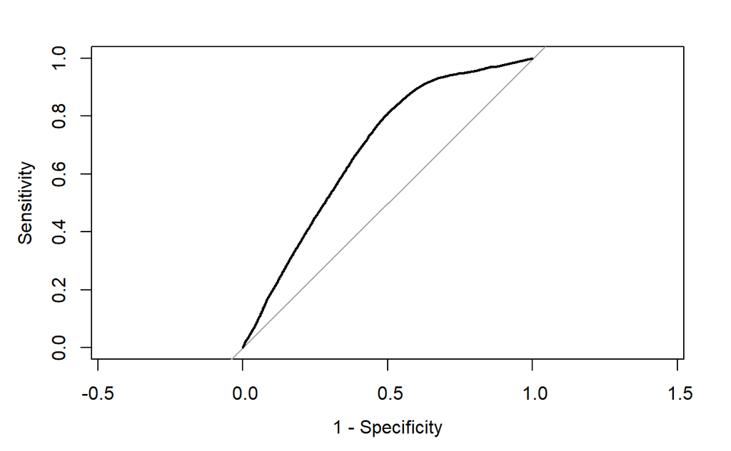

```r
plot(knnRoc, legacy.axes = TRUE)
```

```r
knnRoc$auc
```

```
Area under the curve: 0.6858
```

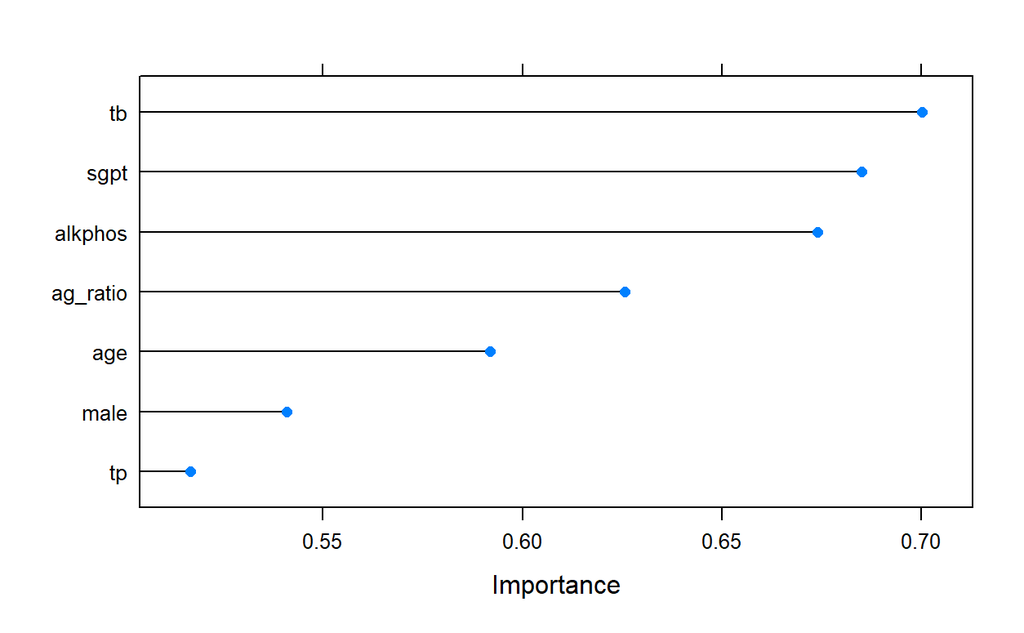

```r
knnImp <- varImp(knnFitTune, scale = FALSE)
plot(knnImp)
```

## Score Test Data

```r
# let's score the test set using this model
pred_class <- predict(knnFitTune, df_test,'raw')
probs <- predict(knnFitTune, df_test,'prob')

# Merge original scaled test dataset with predicions
df_test.scored <- cbind(df[-training,], pred_class, probs)

glimpse(df_test.scored)
```

```
Rows: 116
Columns: 11
$ age        <int> 62, 58, 26, 40, 51, 62, 47, 42, 85, 35, 38, 38, 58, 5~
$ male       <dbl> 1, 1, 0, 0, 1, 1, 1, 1, 0, 1, 1, 1, 1, 1, 1, 1, 0, 0,~
$ tb         <dbl> 10.9, 1.0, 0.9, 0.9, 2.9, 6.8, 2.7, 6.8, 1.0, 1.8, 3.~
$ alkphos    <int> 699, 182, 154, 293, 482, 542, 275, 630, 208, 275, 253~
$ sgpt       <int> 64, 14, 16, 232, 22, 116, 123, 25, 17, 48, 80, 86, 37~
$ tp         <dbl> 7.5, 6.8, 7.0, 6.8, 7.0, 6.4, 6.2, 6.1, 7.0, 6.5, 6.8~
$ ag_ratio   <dbl> 0.74, 1.00, 1.00, 0.80, 0.50, 0.90, 1.10, 0.60, 1.00,~
$ selector   <fct> G1, G1, G1, G1, G1, G1, G1, G2, G2, G2, G1, G1, G1, G~
$ pred_class <fct> G1, G1, G2, G1, G1, G1, G1, G1, G2, G1, G2, G2, G1, G~
$ G1         <dbl> 0.9411765, 0.7058824, 0.4705882, 0.8235294, 0.9411765~
$ G2         <dbl> 0.05882353, 0.29411765, 0.52941176, 0.17647059, 0.058~
```

Random Forest - Bagging

```r
set.seed(476)
rfFit <- train(x = df_train,
               y = selector_train,
               method = "rf",
               metric = "ROC",
               trControl = ctrl)
rfFit
```

```
Random Forest

466 samples
  7 predictor
  2 classes: 'G1', 'G2'

No pre-processing
Resampling: Cross-Validated (10 fold, repeated 10 times)
Summary of sample sizes: 419, 420, 419, 419, 419, 420, ...
Resampling results across tuning parameters:

  mtry  ROC        Sens       Spec
  2     0.7581524  0.8782620  0.3140110
  4     0.7503996  0.8641266  0.3331319
  7     0.7432139  0.8569073  0.3478571

ROC was used to select the optimal model using the largest value.
The final value used for the model was mtry = 2.
```

```r
rfFit$finalModel
```

```
Call:
 randomForest(x = x, y = y, mtry = min(param$mtry, ncol(x)))
               Type of random forest: classification
                     Number of trees: 500
No. of variables tried at each split: 2

        OOB estimate of  error rate: 28.76%
Confusion matrix:
    G1 G2 class.error
G1 289 43   0.1295181
G2  91 43   0.6791045
```

## Validation and testing (model tuning and evaluation)

```r
# we will make a grid of values to test in cross-validation.
rfGrid <-  expand.grid(.mtry = c(1:10))

set.seed(476)
rfFitTune <- train(x = df_train,
               y = selector_train,
               method = "rf",
               metric = "ROC",
               tuneGrid = rfGrid,
               trControl = ctrl)
rfFitTune
```

```
Random Forest

466 samples
  7 predictor
  2 classes: 'G1', 'G2'

No pre-processing
Resampling: Cross-Validated (10 fold, repeated 10 times)
Summary of sample sizes: 419, 420, 419, 419, 419, 420, ...
Resampling results across tuning parameters:

  mtry  ROC        Sens       Spec
   1    0.7587195  0.9547772  0.1248352
   2    0.7575449  0.8786185  0.3176374
   3    0.7541853  0.8647415  0.3394505
   4    0.7509693  0.8638057  0.3340110
   5    0.7478579  0.8626381  0.3354396
   6    0.7449785  0.8569073  0.3417582
   7    0.7424394  0.8592692  0.3398901
   8    0.7435504  0.8598752  0.3468132
   9    0.7428861  0.8593226  0.3555495
  10    0.7435147  0.8587077  0.3544505

ROC was used to select the optimal model using the largest value.
The final value used for the model was mtry = 1.
```

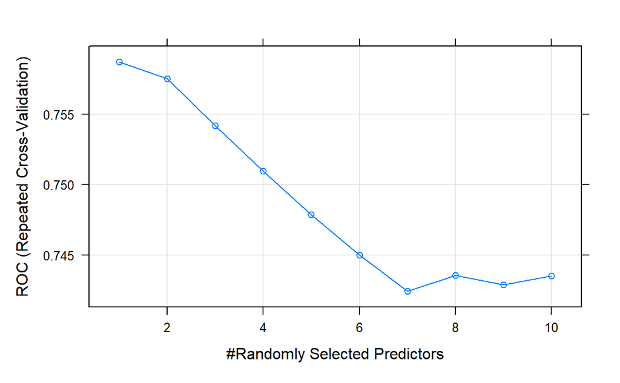

```r
plot(rfFitTune)
```

```r
rfFitTune$finalModel
```

```
Call:
 randomForest(x = x, y = y, mtry = min(param$mtry, ncol(x)))
               Type of random forest: classification
                     Number of trees: 500
No. of variables tried at each split: 1

        OOB estimate of  error rate: 29.61%
Confusion matrix:
    G1 G2 class.error
G1 313 19  0.05722892
G2 119 15  0.88805970
```

## Evaluating the Model

```r
prediction <- predict(rfFitTune,df_test)
confusionMatrix(prediction,selector_test)
```

```
Confusion Matrix and Statistics

          Reference
Prediction G1 G2
        G1 82 30
        G2  1  3

               Accuracy : 0.7328
                 95% CI : (0.6426, 0.8107)
    No Information Rate : 0.7155
    P-Value [Acc > NIR] : 0.384

                  Kappa : 0.1072

 Mcnemar's Test P-Value : 4.932e-07

            Sensitivity : 0.98795
            Specificity : 0.09091
         Pos Pred Value : 0.73214
         Neg Pred Value : 0.75000
             Prevalence : 0.71552
         Detection Rate : 0.70690
   Detection Prevalence : 0.96552
      Balanced Accuracy : 0.53943

       'Positive' Class : G1
```

C5.0 - Boosting

```r
set.seed(476)
CFit <- train(x = df_train,
               y = selector_train,
               method = "C5.0",
               metric = "ROC",
               trControl = ctrl)
CFit
```

```
C5.0

466 samples
  7 predictor
  2 classes: 'G1', 'G2'

No pre-processing
Resampling: Cross-Validated (10 fold, repeated 10 times)
Summary of sample sizes: 419, 420, 419, 419, 419, 420, ...
Resampling results across tuning parameters:

  model  winnow  trials  ROC        Sens       Spec
  rules  FALSE    1      0.5554638  0.8718627  0.2037363
  rules  FALSE   10      0.6788673  0.8555526  0.3068132
  rules  FALSE   20      0.6788975  0.8543672  0.3083516
  rules   TRUE    1      0.5256115  0.9377273  0.1020879
  rules   TRUE   10      0.5814747  0.9289750  0.1318681
  rules   TRUE   20      0.5814747  0.9289750  0.1318681
  tree   FALSE    1      0.6470098  0.8495989  0.2407692
  tree   FALSE   10      0.6737028  0.8425579  0.3186813
  tree   FALSE   20      0.6736349  0.8416578  0.3217582
  tree    TRUE    1      0.5806196  0.9251159  0.1168681
  tree    TRUE   10      0.5977368  0.9187255  0.1573077
  tree    TRUE   20      0.5977368  0.9187255  0.1573077

ROC was used to select the optimal model using the largest value.
The final values used for the model were trials = 20, model = rules
 and winnow = FALSE.
```

```r
CFit$finalModel
```

```
Call:
(function (x, y, trials = 1, rules = FALSE, weights = NULL, control
 2, fuzzyThreshold = FALSE, sample = 0, earlyStopping = TRUE, label
 = "outcome", seed = 1596L))

Rule-Based Model
Number of samples: 466
Number of predictors: 7

Number of boosting iterations: 20 requested;  3 used due to early stopping
Average number of rules: 6

Non-standard options: attempt to group attributes
```

## Validation and testing (model tuning and evaluation)

```r
# we will make a grid of values to test in cross-validation.
CGrid <-  expand.grid(.trials= c(1,5,10,15,20), .winnow= c(TRUE,FALSE), .model= "tree")

set.seed(476)
CFitTune <- train(x = df_train,
               y = selector_train,
               method = "C5.0",
               metric = "ROC",
               tuneGrid = CGrid,
               trControl = ctrl)
CFitTune
```

```
C5.0

466 samples
  7 predictor
  2 classes: 'G1', 'G2'

No pre-processing
Resampling: Cross-Validated (10 fold, repeated 10 times)
Summary of sample sizes: 419, 420, 419, 419, 419, 420, ...
Resampling results across tuning parameters:

  winnow  trials  ROC        Sens       Spec
  FALSE    1      0.6470098  0.8495989  0.2407692
  FALSE    5      0.6726378  0.8413725  0.3205495
  FALSE   10      0.6737028  0.8425579  0.3186813
  FALSE   15      0.6736349  0.8416578  0.3217582
  FALSE   20      0.6736349  0.8416578  0.3217582
   TRUE    1      0.5806196  0.9251159  0.1168681
   TRUE    5      0.5977042  0.9187344  0.1587912
   TRUE   10      0.5977368  0.9187255  0.1573077
   TRUE   15      0.5977368  0.9187255  0.1573077
   TRUE   20      0.5977368  0.9187255  0.1573077

Tuning parameter 'model' was held constant at a value of tree
ROC was used to select the optimal model using the largest value.
The final values used for the model were trials = 10, model = tree
 and winnow = FALSE.
```

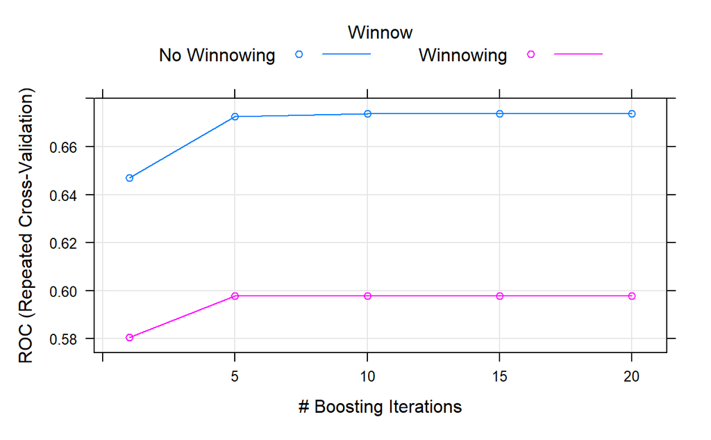

```r
plot(CFitTune)
```

```r
CFitTune$finalModel
```

```
Call:
(function (x, y, trials = 1, rules = FALSE, weights = NULL, control
 2, fuzzyThreshold = FALSE, sample = 0, earlyStopping = TRUE, label
 = "outcome", seed = 1597L))

Classification Tree
Number of samples: 466
Number of predictors: 7

Number of boosting iterations: 10 requested;  5 used due to early stopping
Average tree size: 7.2

Non-standard options: attempt to group attributes
```

## Evaluating the Model

```r
predictions <- predict(CFitTune,df_test)
confusionMatrix(predictions,selector_test)
```

```
Confusion Matrix and Statistics

          Reference
Prediction G1 G2
        G1 71 22
        G2 12 11

               Accuracy : 0.7069
                 95% CI : (0.6152, 0.7877)
    No Information Rate : 0.7155
    P-Value [Acc > NIR] : 0.6262

                  Kappa : 0.2077

 Mcnemar's Test P-Value : 0.1227

            Sensitivity : 0.8554
            Specificity : 0.3333
         Pos Pred Value : 0.7634
         Neg Pred Value : 0.4783
             Prevalence : 0.7155
         Detection Rate : 0.6121
   Detection Prevalence : 0.8017
      Balanced Accuracy : 0.5944

       'Positive' Class : G1
```